# GDP Analysis

```python
import numpy as np
import matplotlib.pyplot as plt
```

```python
import pandas as pd
```

```python
import seaborn as sns
```

```python
# we need this command to remove some warning messages
pd.options.mode.chained_assignment = None  # default='warn'
```

```python
### Let's load the gapminder dataset
gapminder = pd.read_csv('https://raw.githubusercontent.com/thousandoaks/BEMM458/master/data/gapminder.tsv', sep='\t')
```

```python
gapminder.groupby(['country','continent','year']).count()
```

| country | continent | year | lifeExp | pop | gdpPercap |
| --- | --- | --- | --- | --- | --- |
| Afghanistan | Asia | 1952 | 1 | 1 | 1 |
|  |  | 1957 | 1 | 1 | 1 |
|  |  | 1962 | 1 | 1 | 1 |
|  |  | 1967 | 1 | 1 | 1 |
|  |  | 1972 | 1 | 1 | 1 |
| ... | ... | ... | ... | ... | ... |
| Zimbabwe | Africa | 1987 | 1 | 1 | 1 |
|  |  | 1992 | 1 | 1 | 1 |
|  |  | 1997 | 1 | 1 | 1 |
|  |  | 2002 | 1 | 1 | 1 |
|  |  | 2007 | 1 | 1 | 1 |

1704 rows × 3 columns

```python
gapminder.groupby(['continent','year']).count()
```

| continent | year | country | lifeExp | pop | gdpPercap |
| --- | --- | --- | --- | --- | --- |
| Africa | 1952 | 52 | 52 | 52 | 52 |
|  | 1957 | 52 | 52 | 52 | 52 |
|  | 1962 | 52 | 52 | 52 | 52 |
|  | 1967 | 52 | 52 | 52 | 52 |
|  | 1972 | 52 | 52 | 52 | 52 |
|  | 1977 | 52 | 52 | 52 | 52 |
|  | 1982 | 52 | 52 | 52 | 52 |
|  | 1987 | 52 | 52 | 52 | 52 |
|  | 1992 | 52 | 52 | 52 | 52 |
|  | 1997 | 52 | 52 | 52 | 52 |
|  | 2002 | 52 | 52 | 52 | 52 |
|  | 2007 | 52 | 52 | 52 | 52 |
| Americas | 1952 | 25 | 25 | 25 | 25 |
|  | 1957 | 25 | 25 | 25 | 25 |
|  | 1962 | 25 | 25 | 25 | 25 |
|  | 1967 | 25 | 25 | 25 | 25 |
|  | 1972 | 25 | 25 | 25 | 25 |
|  | 1977 | 25 | 25 | 25 | 25 |
|  | 1982 | 25 | 25 | 25 | 25 |
|  | 1987 | 25 | 25 | 25 | 25 |
|  | 1992 | 25 | 25 | 25 | 25 |
|  | 1997 | 25 | 25 | 25 | 25 |
|  | 2002 | 25 | 25 | 25 | 25 |
|  | 2007 | 25 | 25 | 25 | 25 |
| Asia | 1952 | 33 | 33 | 33 | 33 |
|  | 1957 | 33 | 33 | 33 | 33 |
|  | 1962 | 33 | 33 | 33 | 33 |
|  | 1967 | 33 | 33 | 33 | 33 |
|  | 1972 | 33 | 33 | 33 | 33 |
|  | 1977 | 33 | 33 | 33 | 33 |
|  | 1982 | 33 | 33 | 33 | 33 |
|  | 1987 | 33 | 33 | 33 | 33 |
|  | 1992 | 33 | 33 | 33 | 33 |
|  | 1997 | 33 | 33 | 33 | 33 |
|  | 2002 | 33 | 33 | 33 | 33 |
|  | 2007 | 33 | 33 | 33 | 33 |
| Europe | 1952 | 30 | 30 | 30 | 30 |
|  | 1957 | 30 | 30 | 30 | 30 |
|  | 1962 | 30 | 30 | 30 | 30 |
|  | 1967 | 30 | 30 | 30 | 30 |
|  | 1972 | 30 | 30 | 30 | 30 |
|  | 1977 | 30 | 30 | 30 | 30 |
|  | 1982 | 30 | 30 | 30 | 30 |
|  | 1987 | 30 | 30 | 30 | 30 |
|  | 1992 | 30 | 30 | 30 | 30 |
|  | 1997 | 30 | 30 | 30 | 30 |
|  | 2002 | 30 | 30 | 30 | 30 |
|  | 2007 | 30 | 30 | 30 | 30 |
| Oceania | 1952 | 2 | 2 | 2 | 2 |
|  | 1957 | 2 | 2 | 2 | 2 |
|  | 1962 | 2 | 2 | 2 | 2 |
|  | 1967 | 2 | 2 | 2 | 2 |
|  | 1972 | 2 | 2 | 2 | 2 |
|  | 1977 | 2 | 2 | 2 | 2 |
|  | 1982 | 2 | 2 | 2 | 2 |
|  | 1987 | 2 | 2 | 2 | 2 |
|  | 1992 | 2 | 2 | 2 | 2 |
|  | 1997 | 2 | 2 | 2 | 2 |
|  | 2002 | 2 | 2 | 2 | 2 |
|  | 2007 | 2 | 2 | 2 | 2 |

```python
gapminder.sample(10)
```

|  | country | continent | year | lifeExp | pop | gdpPercap |
| --- | --- | --- | --- | --- | --- | --- |
| 1443 | Sudan | Africa | 1967 | 42.858 | 12716129 | 1687.997641 |
| 1614 | United States | Americas | 1982 | 74.650 | 232187835 | 25009.559140 |
| 1391 | Slovenia | Europe | 2007 | 77.926 | 2009245 | 25768.257590 |
| 63 | Australia | Oceania | 1967 | 71.100 | 11872264 | 14526.124650 |
| 150 | Bosnia and Herzegovina | Europe | 1982 | 70.690 | 4172693 | 4126.613157 |
| 490 | Equatorial Guinea | Africa | 2002 | 49.348 | 495627 | 7703.495900 |
| 1119 | Niger | Africa | 1967 | 40.118 | 4534062 | 1054.384891 |
| 1015 | Montenegro | Europe | 1987 | 74.865 | 569473 | 11732.510170 |
| 1268 | Reunion | Africa | 1992 | 73.615 | 622191 | 6101.255823 |
| 894 | Liberia | Africa | 1982 | 44.852 | 1956875 | 572.199569 |

## Which economies in Asia grew the most in absolute terms ?

Economic growth of any country is measured by analysing annual GDP of that specific country with respective time. Estimation of GDP i.e Gross Domestic Product and increse in population, plays vital role while measuring economic growth of country.

```python
#Subsetting data of asia from the whole dataset.
AsianEco = gapminder[gapminder['continent'] == "Asia"]
```

```python
AsianEco.head()
```

|  | country | continent | year | lifeExp | pop | gdpPercap |
| --- | --- | --- | --- | --- | --- | --- |
| 0 | Afghanistan | Asia | 1952 | 28.801 | 8425333 | 779.445314 |
| 1 | Afghanistan | Asia | 1957 | 30.332 | 9240934 | 820.853030 |
| 2 | Afghanistan | Asia | 1962 | 31.997 | 10267083 | 853.100710 |
| 3 | Afghanistan | Asia | 1967 | 34.020 | 11537966 | 836.197138 |
| 4 | Afghanistan | Asia | 1972 | 36.088 | 13079460 | 739.981106 |

```python
AsianEco["GDP"]=AsianEco["gdpPercap"] * AsianEco["pop"]
```

```python
AsianEco
```

|  | country | continent | year | lifeExp | pop | gdpPercap | GDP |
| --- | --- | --- | --- | --- | --- | --- | --- |
| 0 | Afghanistan | Asia | 1952 | 28.801 | 8425333 | 779.445314 | 6.567086e+09 |
| 1 | Afghanistan | Asia | 1957 | 30.332 | 9240934 | 820.853030 | 7.585449e+09 |
| 2 | Afghanistan | Asia | 1962 | 31.997 | 10267083 | 853.100710 | 8.758856e+09 |
| 3 | Afghanistan | Asia | 1967 | 34.020 | 11537966 | 836.197138 | 9.648014e+09 |
| 4 | Afghanistan | Asia | 1972 | 36.088 | 13079460 | 739.981106 | 9.678553e+09 |
| ... | ... | ... | ... | ... | ... | ... | ... |
| 1675 | Yemen, Rep. | Asia | 1987 | 52.922 | 11219340 | 1971.741538 | 2.212164e+10 |
| 1676 | Yemen, Rep. | Asia | 1992 | 55.599 | 13367997 | 1879.496673 | 2.512511e+10 |
| 1677 | Yemen, Rep. | Asia | 1997 | 58.020 | 15826497 | 2117.484526 | 3.351236e+10 |
| 1678 | Yemen, Rep. | Asia | 2002 | 60.308 | 18701257 | 2234.820827 | 4.179396e+10 |
| 1679 | Yemen, Rep. | Asia | 2007 | 62.698 | 22211743 | 2280.769906 | 5.065987e+10 |

396 rows × 7 columns

```python
df1952= AsianEco[AsianEco['year']== 1952]
df2007= AsianEco[AsianEco['year'] == 2007]
```

```python
#Subset the data according to Years
gapminder1952=df1952[['country','lifeExp','GDP']]
gapminder2007=df2007[['country','lifeExp','GDP']]
```

```python
gapminder1952.sample(10)
```

|  | country | lifeExp | GDP |
| --- | --- | --- | --- |
| 756 | Israel | 65.390 | 6.623901e+09 |
| 852 | Kuwait | 55.565 | 1.734118e+10 |
| 288 | China | 44.000 | 2.227550e+11 |
| 840 | Korea, Rep. | 47.453 | 2.158840e+10 |
| 1488 | Syria | 45.883 | 6.017702e+09 |
| 720 | Iran | 44.869 | 5.242615e+10 |
| 1356 | Singapore | 60.396 | 2.609161e+09 |
| 1044 | Myanmar | 36.319 | 6.650782e+09 |
| 1644 | Vietnam | 40.412 | 1.588108e+10 |
| 1656 | West Bank and Gaza | 43.160 | 1.561947e+09 |

```python
EcoInfo = pd.merge(gapminder1952,gapminder2007,how='left' ,on='country')
```

```python
EcoInfo.sample(10)
```

|  | country | lifeExp_x | GDP_x | lifeExp_y | GDP_y |
| --- | --- | --- | --- | --- | --- |
| 1 | Bahrain | 50.939 | 1.188461e+09 | 75.635 | 2.111268e+10 |
| 21 | Oman | 37.578 | 9.284357e+08 | 75.640 | 7.152110e+10 |
| 0 | Afghanistan | 28.801 | 6.567086e+09 | 43.828 | 3.107929e+10 |
| 22 | Pakistan | 43.436 | 2.830574e+10 | 65.483 | 4.411104e+11 |
| 24 | Saudi Arabia | 39.875 | 2.587489e+10 | 72.777 | 5.976958e+11 |
| 16 | Lebanon | 55.928 | 6.959841e+09 | 71.993 | 4.102072e+10 |
| 14 | Korea, Rep. | 47.453 | 2.158840e+10 | 78.623 | 1.145105e+12 |
| 32 | Yemen, Rep. | 32.548 | 3.880312e+09 | 62.698 | 5.065987e+10 |
| 6 | India | 37.373 | 2.033225e+11 | 64.698 | 2.722925e+12 |
| 31 | West Bank and Gaza | 43.160 | 1.561947e+09 | 73.422 | 1.215686e+10 |

```python
EcoInfo=EcoInfo.rename(columns={"lifeExp_x": "lifeExp52",
                          "lifeExp_y": "lifeExp07","GDP_x":"GDP52","GDP_y":"GDP07"})
```

```python
EcoInfo.sample(10)
```

|  | country | lifeExp52 | GDP52 | lifeExp07 | GDP07 |
| --- | --- | --- | --- | --- | --- |
| 15 | Kuwait | 55.565 | 1.734118e+10 | 77.588 | 1.185305e+11 |
| 27 | Syria | 45.883 | 6.017702e+09 | 74.143 | 8.082349e+10 |
| 20 | Nepal | 36.157 | 5.012432e+09 | 63.785 | 3.154225e+10 |
| 12 | Jordan | 43.158 | 9.403869e+08 | 72.535 | 2.735717e+10 |
| 23 | Philippines | 47.752 | 2.856178e+10 | 71.688 | 2.905804e+11 |
| 22 | Pakistan | 43.436 | 2.830574e+10 | 65.483 | 4.411104e+11 |
| 32 | Yemen, Rep. | 32.548 | 3.880312e+09 | 62.698 | 5.065987e+10 |
| 16 | Lebanon | 55.928 | 6.959841e+09 | 71.993 | 4.102072e+10 |
| 21 | Oman | 37.578 | 9.284357e+08 | 75.640 | 7.152110e+10 |
| 18 | Mongolia | 42.244 | 6.297750e+08 | 66.803 | 8.897643e+09 |

```python
## Created new column
EcoInfo['increase_lfExp'] = EcoInfo['lifeExp07'] - EcoInfo['lifeExp52']
EcoInfo['increase_GDP'] = EcoInfo['GDP07'] - EcoInfo['GDP52']
```

```python
EcoInfo.sample(5)
```

|  | country | lifeExp52 | GDP52 | lifeExp07 | GDP07 | increase_lfExp | increase_GDP |
| --- | --- | --- | --- | --- | --- | --- | --- |
| 12 | Jordan | 43.158 | 9.403869e+08 | 72.535 | 2.735717e+10 | 29.377 | 2.641678e+10 |
| 18 | Mongolia | 42.244 | 6.297750e+08 | 66.803 | 8.897643e+09 | 24.559 | 8.267868e+09 |
| 16 | Lebanon | 55.928 | 6.959841e+09 | 71.993 | 4.102072e+10 | 16.065 | 3.406088e+10 |
| 13 | Korea, Dem. Rep. | 50.056 | 9.648113e+09 | 67.297 | 3.712117e+10 | 17.241 | 2.747306e+10 |
| 26 | Sri Lanka | 57.593 | 8.649123e+09 | 72.396 | 8.090355e+10 | 14.803 | 7.225443e+10 |

```python
#subset the data according to the GDP and Life expactancy increase.
GrowthWiseLifeExp=EcoInfo[['country','increase_lfExp']]
GrowthWiseGDP=EcoInfo[['country','increase_GDP']]

#data sorted accordingly.
GrowthWiseLifeExpSorted = GrowthWiseLifeExp.sort_values('increase_lfExp', ascending=False)
GrowthWiseGDPSorted = GrowthWiseGDP.sort_values('increase_GDP', ascending=False)

#top 5 countries taken out for the dataset.
GrowthWiseLifeExp1st5=GrowthWiseLifeExpSorted.iloc[0:5]
GrowthWiseGDP1st5=GrowthWiseGDPSorted.iloc[0:5]

#index reset.
GrowthWiseLifeExp1st5=GrowthWiseLifeExp1st5.reset_index()
GrowthWiseGDP1st5=GrowthWiseGDP1st5.reset_index()


GrowthWiseLifeExp1st5= GrowthWiseLifeExp1st5.drop(['index'], axis=1)
GrowthWiseGDP1st5= GrowthWiseGDP1st5.drop(['index'], axis=1)
```

```python
##Economic Growth of Country as per Life Expectancy
```

```python
GrowthWiseLifeExp1st5
```

|  | country | increase_lfExp |
| --- | --- | --- |
| 0 | Oman | 38.062 |
| 1 | Vietnam | 33.837 |
| 2 | Indonesia | 33.182 |
| 3 | Saudi Arabia | 32.902 |
| 4 | Korea, Rep. | 31.170 |

```python
UniqueC = ['Oman', 'Vietnam','Indonesia','Korea, Rep.','Saudi Arabia']
DataCountry = AsianEco.loc[AsianEco['country'].isin(UniqueC )]
```

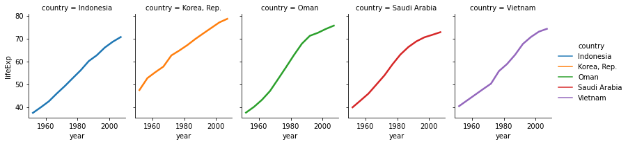

```python
sns.relplot(x="year", y="lifeExp", kind="line",hue = "country",
            col="country", col_wrap=5,
            height=3, aspect=.75, linewidth=2.5, data=DataCountry);
```

```python
#Economic Growth of Country as per GDP
GrowthWiseGDP1st5
```

|  | country | increase_GDP |
| --- | --- | --- |
| 0 | China | 6.316746e+12 |
| 1 | Japan | 3.757000e+12 |
| 2 | India | 2.519603e+12 |
| 3 | Korea, Rep. | 1.123516e+12 |
| 4 | Iran | 7.536322e+11 |

```python
UniqueC = ['China', 'Japan','Iran','Korea, Rep.','India']
DataCountry = AsianEco.loc[AsianEco['country'].isin(UniqueC )]
```

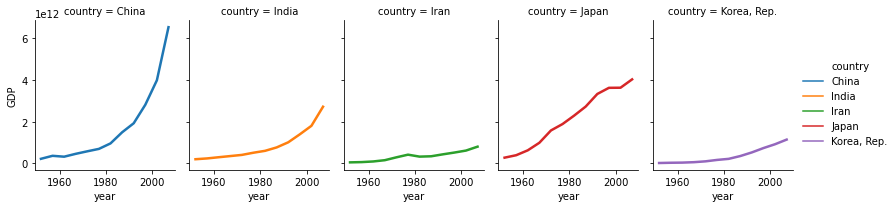

```python
sns.relplot(x="year", y="GDP", kind="line",hue = "country",
            col="country", col_wrap=5,
            height=3, aspect=.75, linewidth=2.5, data=DataCountry);
```

As we can see in the above graphs that the china shows the highest Economic Growth in absolute terms followed by Japan and India. However, Oman shows the highest increase in Economic growth in terms of the Life expectancy followed by Viatnam and Indonasia.

## Which economies in Asia grew the most in relative terms ?

## Defining growth in terms of incremental evolution of GDP and life expectancy

```python
UniYear = pd.DataFrame(index=AsianEco.year.unique())

for count in (AsianEco.country.unique()):
    df = AsianEco[AsianEco['country']==count]
    df = (df.drop(['country','continent'],axis = 1).sort_values(by='year'))
    df[count] = df['pop']*df['gdpPercap']

    df.set_index('year',inplace = True)
    init_Val = df[count].iloc[0]
    df_GDP =  df[count]/init_Val * 100

    UniYear = UniYear.join(df_GDP)
```

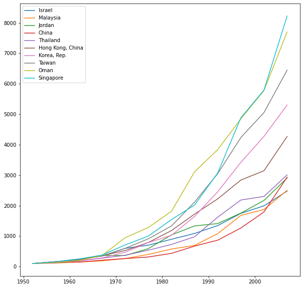

```python
list_top_10 = list(((UniYear.T[2007].sort_values().tail(10)).to_frame()).index)
UniYear[list_top_10].plot(kind='line', subplots=False,figsize=(10,10))
```

As illustrated in above graph economy of Singapore is showing maximum Economic growth in relative terms followed by economy of Oman.

## Is there any relationship between GDP Per Capita and life Expectancy ?

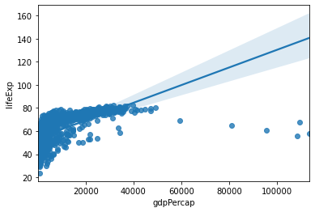

```python
sns.regplot(x="gdpPercap", y="lifeExp", data=gapminder);
```

Yes, there is relationship between GDP per Capita and Life Expectancy as GDP increases Life Expectancy also increase. We can also see there that there almost none of the country with gdpPercap more than the 20000 has life expactancy less than 40 years.

[figure not shown]

```python
sns.jointplot(
    data=gapminder,
    x="gdpPercap", y="lifeExp", hue="year",
    kind="kde",
)
```

We can see the same interpretation using the joint kernel density estimate visualization

## Has the relationship between GDP Per Capita and life Expectancy changed with time ?

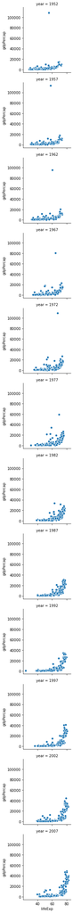

```python
mlp = sns.FacetGrid(gapminder,row="year")

mlp.map(sns.scatterplot, "lifeExp","gdpPercap")
```

Yes, relationship between GDP Per Capita and Life Expectancy has been changed over time. Observing this relationship from 1952 its clear that rise in GDP and Life Expectancy showing regular growth.